# Coloc Wrapper Example

## Evaluating the results

### Coloc results

Columns:

- `gene`: gene ID
- `nsnps`: number of SNPs analysed
- `PP.H0.abf`: posterior probabilitiy of H0 (no causal variant)
- `PP.H1.abf`: posterior probability of H1 (causal variant for trait 1 only)
- `PP.H2.abf`: posterior probability of H2 (causal variant for trait 2 only)
- `PP.H3.abf`: posterior probability of H3 (two distinct causal variants)
- `PP.H4.abf`: posterior probability of H4 (one common causal variant)

| gene | nsnps | PP.H0.abf | PP.H1.abf | PP.H2.abf | PP.H3.abf | PP.H4.abf |
| --- | --- | --- | --- | --- | --- | --- |
| ENSG00000064651.14_5_128114212_128114287 | 5880 | 0 | 0.0050366 | 0 | 0.0369369 | 0.9580265 |
| ENSG00000064651.14_5_128114586_128114681 | 5882 | 0 | 0.0039384 | 0 | 0.0210036 | 0.9750580 |
| ENSG00000064651.14_5_128131067_128131206 | 5873 | 0 | 0.0012455 | 0 | 0.0273128 | 0.9714417 |
| ENSG00000064651.14_5_128134165_128134275 | 5870 | 0 | 0.0057714 | 0 | 0.1004439 | 0.8937847 |
| ENSG00000064651.14_5_128135700_128135808 | 5875 | 0 | 0.0324131 | 0 | 0.0709382 | 0.8966487 |
| ENSG00000064651.14_5_128138597_128138724 | 5890 | 0 | 0.0211224 | 0 | 0.0455368 | 0.9333408 |
| ENSG00000064651.14_5_128138824_128138908 | 5890 | 0 | 0.0113976 | 0 | 0.0322919 | 0.9563106 |
| ENSG00000064651.14_5_128141830_128141981 | 5912 | 0 | 0.0013968 | 0 | 0.0208164 | 0.9777868 |

### Locuscompare plot

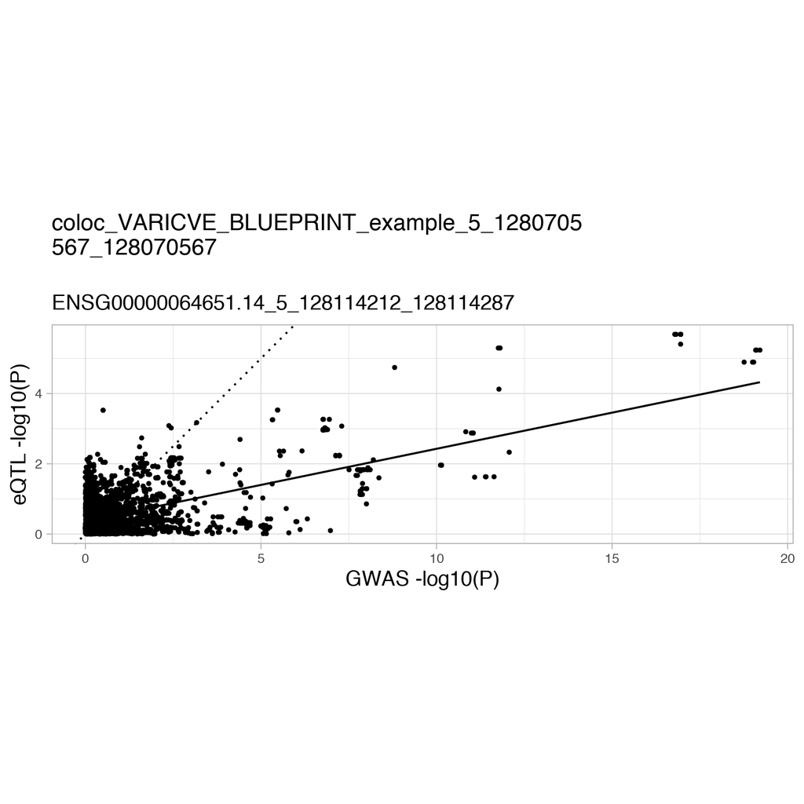